# Introducción a distribuciones de probabilidad

Moises

20/3/2020

## Conceptos básicos

Experimento aleatorio

Experimento aleatorio. Experimento que efectuado en las mismas condiciones puede dar lugar a resultados diferentes

Suceso elemental. Cada uno de los posibles resultados del experimento aleatorio

Espacio muestral. Conjunto Ω formado por todos los sucesos elementales del experimento aleatorio

## Ejemplo

Lanzar una moneda es un experimento aleatorio

Los sucesos elementales son: sacar cara (C) y sacar cruz (+)

El espacio muestral de este experimento aleatorio es Ω={C,+}

## Sucesos

Suceso. Subconjunto del espacio muestral

Suceso total o seguro. Ω

Suceso vacío o imposible. ∅

## Ejemplo

Lanzar un dado es un experimento aleatorio

Algunos sucesos podrían ser: sacar número par ({2,4,6}), sacar mayor que 4 ({5,6}), sacar número múltiplo de 3 ({3,6})…

El suceso total de este experimento aleatorio es Ω={1,2,3,4,5,6}

Un ejemplo de suceso imposible de este experimento aleatorio es ∅={7} (sacar 7)

## Sucesos

Operaciones con sucesos. Sean A,B⊆Ω sucesos. Entonces, A∪B es el suceso unión (resultados pertenecen a A, o a B, o a ambos) A∩B es el suceso intersección (resultados pertenecen a A y B ) Ac es el suceso complementario (resultados que no pertenecen a A) A−B=A∩Bc es el suceso diferencia (resultados que pertenecen a A pero no a B)

Sucesos incompatibles. Si A∩B=∅

## Probabilidad

Probabilidad de un suceso. Número entre 0 y 1 (ambos incluidos) que mide la expectativa de que se dé este suceso

## Probabilidad

Probabilidad. Sea Ω el espacio muestral de un experimento aleatorio. Suponiendo que Ω es finito, una probabilidad sobre Ω es una aplicación

que satisface

0≤p(A)≤1 ∀A∈P(Ω) p(Ω)=1 Si {A1,…,An} son sucesos incompatibles dos a dos (Ai∩Aj=∅ ∀i≠j), entonces p(A1∪⋯∪An)=p(A1)+⋯+p(An)

Notación: Si a∈Ω, escribiremos p(a) en vez de p({a})

## Variable aleatoria

Variable aleatoria. Una variable aleatoria (v.a.) sobre Ω es una aplicación X:Ω⟶R que asigna a cada suceso elemental ω un número real X(ω)

Puede entenderse como una descripción numérica de los resultados de un experimento aleatorio

Dominio de una variable aleatoria. DX, es el conjunto de los valores que puede tomar

## Función de distribución

Función de distribución de la v.a. X. Es una función F:R⟶[0,1] definida por F(x)=p(X≤x)

Sea F una función de distribución de una v.a. X y digamos F(a−)=limx→a−F(x) p(X≤a)=F(a) p(X<a)=limb→a, b<ap(X≤b)=limb→a, b<aF(b)=F(a−) p(X=a)=p(X≤a)−p(X<a)=F(a)−F(a−) p(a≤X≤b)=p(X≤b)−p(X<a)=F(b)−F(a−)

## Cuantiles

Cuantil de orden p de una v.a. X. Es el xp∈R más pequeño tal que F(xp)≥p

Nótese que la mediana es el cuantil de orden 0.5

## Variable aleatoria discreta

Variable aleatoria discreta. Una v.a. X:Ω⟶R es discreta cuando DX es finito o un subconjunto de N

Función de probabilidad. Es la función f:R⟶[0,1] definida por f(x)=p(X=x)

Nótese que f(x)=0 si x∉DX. Por tanto, interpretaremos la función de probabilidad como la función f:DX⟶[0,1]

## Esperanza

Esperanza de una v.a. discreta. Sea f:DX⟶[0,1] la función de probabilidad de X, entonces la esperanza respecto de la función de probabilidad es la suma ponderada de los elementos de DX, multiplicando cada elemento x de DX por su probabilidad, E(X)=∑x∈DXx⋅f(x)

Si g:DX⟶R es una aplicación E(g(X))=∑x∈DXg(x)⋅f(x)

## Varianza

Varianza de una v.a. discreta. Sea f:DX⟶[0,1] la función de probabilidad de X, entonces la varianza respecto de la función de probabilidad es el valor esperado de la diferencia al cuadrado entre X y su valor medio E(X), Var(X)=E((X−E(X))2)

La varianza mide como de variados son los resultados de X respecto de la media

## Desviación típica

Desviación típica de una v.a. discreta. Sea f:DX⟶[0,1] la función de probabilidad de X, entonces la desviación típica respecto de la función de probabilidad es

σ(X)=Var(X)−−−−−−√

Las unidades de la varianza son las de X al cuadrado. En cambio, las de la desviación típica son las mismas unidades que las de X

## Distribución de probabilidad

Distribución de probabilidad. En teoría de la probabilidad y estadística, la distribución de probabilidad de una variable aleatoria es una función que asigna a cada suceso definido sobre la variable la probabilidad de que dicho suceso ocurra.

## Distribuciones en R

Dada cualquier variable aleatoria, va, R nos da cuatro funciones para poder trabajar con ellas:

- dva(x,…): Función de densidad o de probabilidad f(x) de la variable aleatoria para el valor x del dominio de definición.
- pva(x,…): Función de distribución F(x) de la variable aleatoria para el valor x del dominio de definición.
- qva(p,…): Cuantil p-ésimo de la variable aleatoria (el valor de x más pequeño tal que F(x)≥p).
- rva(n,…): Generador de n observaciones siguiendo la distribución de la variable aleatoria.

## Distribuciones en Python

Dada cualquier variable aleatoria, en Python tenemos las mismas cuatro funciones, sin que su nombre dependa de la misma:

- pmf(k,…) o pdf(x,…): Función de probabilidad f(k) o de densidad f(x) de la variable aleatoria para los valores k o x del dominio.
- cdf(x,…): Función de distribución F(x) de la variable aleatoria para el valor k del dominio.
- ppf(p,…): Cuantil p-ésimo de la variable aleatoria (el valor de x más pequeño tal que F(x)≥p).
- rvs(size,…): Generador de size observaciones siguiendo la distribución de la variable aleatoria.

También vale la pena conocer la función stats(moments=‘mvsk’) que nos devuelve cuatro valores con los estadísticos de la media m, la varianza v, el sesgo s y la curtosis k de la distribución.

## Distribuciones discretas más conocidas

- Bernoulli
- Binomial
- Geométrica
- Hipergeométrica
- Poisson
- Binomial Negativa

## Distribución de Bernoulli

Si X es variable aleatoria que mide el “número de éxitos” y se realiza un único experimento con dos posibles resultados (éxito, que toma valor 1, o fracaso, que toma valor 0), diremos que X se distribuye como una Bernoulli con parámetro p

X∼Be(p) donde p es la probabilidad de éxito y q=1−p es la probabilidad de fracaso.

- El dominio de X será DX={0,1}

## El código de la distribución de Beroulli:

- En R tenemos las funciones del paquete Rlab: dbenr(x,prob), pbenr(q,prob), qbenr(p,prob), rbenr(n, prob) donde prob es la probabilidad de éxito.
- En Python tenemos las funciones del paquete scipy.stats.bernoulli: pmf(k,p), cdf(k,p), ppf(q,p), rvs(p, size) donde p es la probabilidad de éxito.

## Función de densidad

Sea $X = Be(p=0.7)$, la distribución que modela la probabilidad de obtener una cara usando una moneda trucada.

$$f(k) = p^k(1-p)^{1-p},\ k\in \{0,1\}$$

## En R

```r
library(Rlab)
dbern(0, prob= 0.7)
```

```
## [1] 0.3
```

```r
dbern(1, prob = 0.7)
```

```
## [1] 0.7
```

```r
pbern(0, prob = 0.7)
```

```
## [1] 0.3
```

```r
pbern(1, prob = 0.7)
```

```
## [1] 1
```

```r
qbern(0.5, prob = 0.7) #La mediana osea el cuantil 0.5 osea el 51% de los casos
```

```
## [1] 1
```

```r
qbern(0.25, prob = 0.7) #El cuantil 0.25 osea el 25% de los casos
```

```
## [1] 0
```

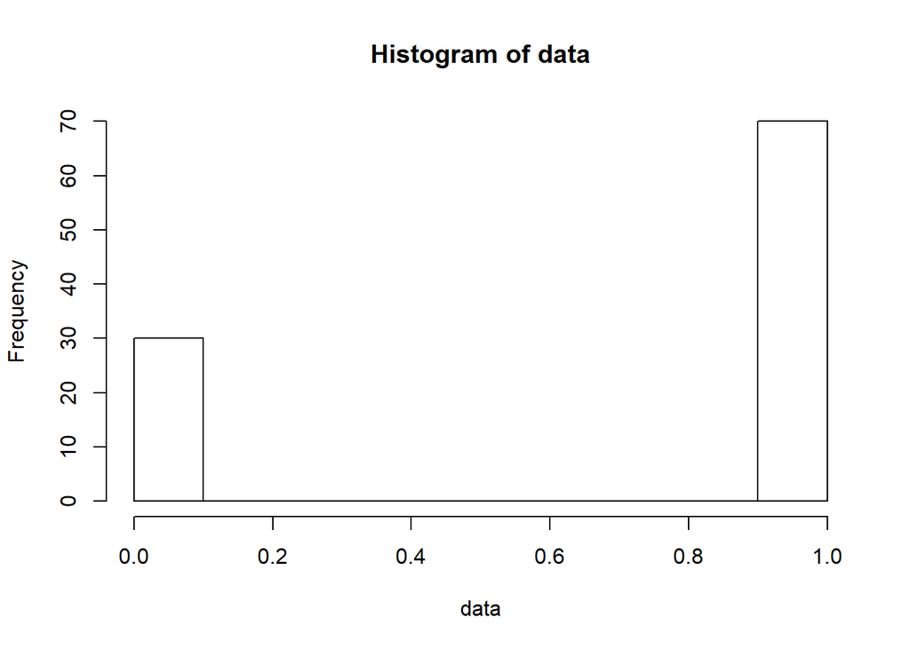

```r
rbern(100, prob = 0.7) -> data #Para generar n numeros aletarios con x propabilidad 0 1
hist(data)
```

```r
library(reticulate)
use_python("C:/Users/moise/Anaconda3/python.exe",required = TRUE)
```

## Distribución Binomial

Si X es variable aleatoria que mide el “número de éxitos” y se realizan n ensayos de Bernoulli independientes entre sí, diremos que X se distribuye como una Binomial con parámetros n y p

X∼B(n,p)

donde p es la probabilidad de éxito y q=1−p

es la probabilidad de fracaso

- El dominio de X será DX={0,1,2,…,n}
- La función de probabilidad vendrá dada por f(k)=(nk)pk(1−p)n−k